# IA para Científicos Sociales

Sesión 5.3: Laboratorio 9 - Modelos locales y auditoría de sesgo

Danilo Freire

danilofreire@gmail.com

Department of Data and Decision Sciences  
Emory University

# Laboratorio 9: Modelos locales y auditoría de sesgo

## Objetivos del laboratorio

**Parte 1: un LLM en tu máquina (sesión 5.1)**

1. Verificar Ollama y conversar con [Granite](https://ollama.com/library/granite4.1) desde la terminal y desde R
2. Codificar datos sensibles (simulados) con `quallmer` y el modelo local
3. Validar la codificación contra un gold standard humano

**Parte 2: auditoría de equidad (sesión 5.2)**

4. Auditar un modelo de crédito con [`fairmodels`](https://modeloriented.github.io/fairmodels/index.html)
5. Calcular e interpretar métricas de equidad por grupo
6. Discutir mitigación y sus trade-offs

Las dos partes son las dos caras de la ética de hoy: proteger los datos de las personas y verificar que nuestros modelos no las traten de forma desigual

# Parte 1: Un LLM en tu máquina

## Verificar la instalación

En la terminal (no en R), verificá que Ollama está instalado y bajá el modelo de hoy:

```bash
ollama --version
ollama pull granite4.1:3b
```

[IBM Granite](https://www.ibm.com/granite) (~2,1 GB) responde directo, sin razonar antes, y está afinado para salida estructurada. Para codificar es justo lo que queremos: rápido y estable

**Probarlo en la terminal**

```bash
ollama run granite4.1:3b
```

Escribí un par de preguntas y salí con `/bye`

**¿Por qué no un modelo con razonamiento?**

Hay muchos modelos disponibles, incluso los *thinking models*, que razonan antes de responder. Para chatear están bien, pero para codificar tienen dos problemas:

- “Piensan” uno o dos minutos por cada texto
- En Ollama, apagarles el razonamiento suele romper la salida estructurada que `quallmer` necesita

**Nota**

**Pista**: elegir el modelo correcto es parte del oficio. Un modelo con razonamiento para problemas difíciles; uno directo y afinado para salida estructurada, como Granite, para tareas repetitivas como la codificación

## Conectar desde R

El mismo `ellmer` del lab 7, otro proveedor: `chat_ollama()` en lugar de `chat_openrouter()`. Sin API key, sin internet

```r
R> library(tidyverse)
R> library(ellmer)
R> library(quallmer)
R>
R> chat <- chat_ollama(
+   model = "granite4.1:3b",
+   system_prompt = "Sos un asistente de investigación social. Respondé en español, en una sola oración."
+ )
R>
R> chat$chat("¿Qué es una encuesta de victimización?")
```

```
Una encuesta de victimización es un instrumento utilizado para recopilar
información sobre las experiencias de delitos y amenazas a la seguridad
personal o propiedad de los individuos, mediante preguntas específicas que
evalúan la ocurrencia de tales eventos en un período determinado.
```

La primera llamada tarda unos segundos: el modelo se está cargando en memoria. Las siguientes son más rápidas

## El caso: entrevistas que no pueden salir de la máquina

- Un equipo entrevistó a víctimas de delitos que no hicieron la denuncia (un problema clásico de las encuestas de victimización)
- Los fragmentos contienen detalles identificables: barrios, rutinas, conflictos con vecinos
- El consentimiento informado y el comité de ética prohíben transferir el material a terceros, lo que incluye una API en la nube
- Queremos codificar el motivo principal por el que cada persona no denunció

| Código | Significado |
| --- | --- |
| `desconfianza` | No cree que la policía o la justicia hagan algo |
| `miedo` | Teme represalias del agresor |
| `costo` | El trámite cuesta tiempo o esfuerzo |
| `poca_gravedad` | No consideró el hecho suficientemente grave |
| `resolucion_propia` | Lo resolvió por otra vía |

**Los datos**

```r
R> entrevistas <- read_csv("datos/entrevistas_confianza.csv")
R> # Leé el archivo directo desde la web:
R> # entrevistas <- read_csv("https://raw.githubusercontent.com/danilofreire/introduccion-ia-ucu/main/clases/dia-05/datos/entrevistas_confianza.csv")
R>
R> entrevistas |> count(motivo_humano)
```

```
# A tibble: 5 × 2
  motivo_humano         n
  <chr>             <int>
1 costo                 3
2 desconfianza          4
3 miedo                 3
4 poca_gravedad         3
5 resolucion_propia     3
```

`motivo_humano` es el gold standard: la codificación manual del equipo

**Advertencia**

Los datos son simulados, pero el flujo de trabajo es exactamente el que usarían con entrevistas reales

## Paso 1: definir el codebook

El mismo `qlm_codebook()` del lab 8. La diferencia: la variable es nominal (categorías), no una escala de intervalo

```r
R> codebook_motivos <- qlm_codebook(
+   name = "motivos_no_denuncia",
+   instructions = "Leé el fragmento de entrevista. La persona fue víctima de un delito
+   y no hizo la denuncia. Clasificá el MOTIVO PRINCIPAL en una de estas categorías:
+   - desconfianza: no cree que la policía o la justicia investiguen o resuelvan nada
+   - miedo: teme represalias del agresor o de su entorno
+   - costo: el trámite implica demasiado tiempo, viajes o burocracia
+   - poca_gravedad: considera que el hecho no fue suficientemente grave
+   - resolucion_propia: resolvió el problema por su cuenta o por otra vía
+   Elegí UNA sola categoría, la que mejor capture el motivo central del relato.",
+   schema = type_object(
+     motivo = type_enum(
+       c("desconfianza", "miedo", "costo", "poca_gravedad", "resolucion_propia"),
+       "El motivo principal por el que no denunció"
+     ),
+     justificacion = type_string("Una oración que justifique la categoría elegida")
+   ),
+   role = "Sos un investigador experto en criminología y encuestas de victimización.",
+   levels = list(motivo = "nominal", justificacion = "nominal")
+ )
```

## Paso 2: codificar con el modelo local

El mismo `qlm_code()` de ayer. Lo único que cambia es el string del modelo: `"ollama/..."` en lugar de `"openrouter/..."`

```r
R> codificado <- qlm_code(
+   entrevistas$texto,
+   codebook_motivos,
+   model = "ollama/granite4.1:3b",
+   max_active = 1,
+   params = params(temperature = 0),
+   name = "granite_local"
+ )
```

**Qué está pasando**

- Cada fragmento viaja al servidor local de Ollama, no a internet
- El modelo devuelve la categoría y una justificación, con el esquema garantizado por `type_enum()`

**Advertencia**

`max_active = 1` es importante: el servidor local procesa de a un pedido. Con varios pedidos en paralelo, los demás esperan y dan timeout. No hay errores `400` de la API, pero el paralelismo de la nube acá no existe

## Inspeccionar los resultados

```r
R> resultados <- as_tibble(codificado) |>
+   mutate(texto = str_trunc(entrevistas$texto, 60), gold = entrevistas$motivo_humano) |>
+   select(texto, motivo, gold)
R>
R> resultados
```

```
# A tibble: 16 × 3
   texto                                                        motivo     gold
   <chr>                                                        <fct>      <chr>
 1 Me robaron la moto en la puerta de casa, en el Cerro. No ... desconfia… desc…
 2 Mi vecina vio quién fue y todo, pero ¿para qué voy a denu... desconfia… desc…
 3 A mi hijo le sacaron el celular a la salida del liceo. No... desconfia… desc…
 4 Después de lo que salió en la prensa sobre los policías d... desconfia… desc…
 5 Sé perfectamente quiénes entraron a casa, viven a dos cua... miedo      miedo
 6 El que me amenazó es conocido en el barrio, ya estuvo pre... miedo      miedo
 7 Vi todo desde el balcón, pero no voy a declarar nada. Esa... miedo      miedo
 8 Trabajo de ocho a ocho en una fiambrería y la comisaría m... costo      costo
 9 Empecé a hacer la denuncia por internet y el sistema se c... costo      costo
10 Por una bicicleta usada no vale la pena el trámite. Son h... costo      costo
11 Me sacaron unos pesos del bolso en el ómnibus, habrán sid... poca_grav… poca…
12 Fue un rayón en el auto en el estacionamiento del súper. ... poca_grav… poca…
13 Me rompieron una maceta y se llevaron unas plantas del fr... poca_grav… poca…
14 Al final lo arreglamos entre nosotros. El padre del mucha... resolucio… reso…
15 Supe quién tenía mi bicicleta porque la publicó para vend... resolucio… reso…
16 En el edificio tenemos un grupo y entre todos identificam... resolucio… reso…
```

A simple vista: ¿dónde coincide con el equipo humano y dónde no?

## Paso 3: validar contra el gold standard

```r
R> gold <- qlm_humancoded(
+   tibble(
+     .id = seq_len(nrow(entrevistas)),
+     motivo = entrevistas$motivo_humano
+   ),
+   name = "humano",
+   codebook = codebook_motivos
+ )
R>
R> validacion <- qlm_validate(
+   codificado,
+   gold = gold,
+   by = "motivo",
+   level = "nominal"
+ )
R>
R> as_tibble(validacion) |> select(measure, value)
```

```
# A tibble: 5 × 2
  measure   value
  <chr>     <dbl>
1 accuracy      1
2 precision     1
3 recall        1
4 f1            1
5 kappa         1
```

**Cómo leer esto**

- Accuracy: proporción de coincidencias exactas
- Kappa / alpha: acuerdo corregido por azar. Con 5 categorías, adivinar da ~20%, así que el acuerdo bruto exagera
- La referencia del lab 8 sigue valiendo: kappa ≥ 0,7 para confiar en el codificador

**Pista**: si el modelo local rinde cerca del humano, ganamos un codificador gratuito, privado y reproducible. Si no, el ejercicio 1 muestra el primer remedio: mejorar el codebook

## ¿Dónde se equivoca?

```r
R> resultados |> filter(motivo != gold)
```

```
# A tibble: 0 × 3
# ℹ 3 variables: texto <chr>, motivo <fct>, gold <chr>
```

- Los errores rara vez son aleatorios: suelen concentrarse en fronteras entre categorías (¿“desconfianza” o “miedo”? ¿“costo” o “poca_gravedad”?)
- Esas fronteras confusas también confunden a codificadores humanos. La solución clásica es la misma: reglas de decisión explícitas en el codebook

Ejercicio 1: mejorar el codebook

# Parte 2: Auditoría de equidad

## De los LLMs a nuestros propios modelos

**Lo que acabamos de hacer**

Auditar la calidad de un codificador automático: ¿acierta?

**Lo que sigue**

Auditar la equidad de un clasificador como los de los días 1 y 2: ¿acierta igual para todos los grupos?

**El caso de estudio**

El dataset [German Credit](https://archive.ics.uci.edu/dataset/144/statlog+german+credit+data), un clásico en estudios de sesgo algorítmico:

- 1000 solicitudes de crédito
- Variable objetivo: buen/mal pagador
- Atributo protegido: sexo
- La pregunta de la sesión 5.2: ¿el modelo trata igual a hombres y mujeres?

## Preparación

```r
R> # Instalar paquetes si no están disponibles
R> if (!require("fairmodels")) install.packages("fairmodels")
R> if (!require("DALEX")) install.packages("DALEX")
R>
R> # Cargar paquetes
R> library(tidymodels)
R> library(fairmodels)
R> library(DALEX)
```

[`fairmodels`](https://modeloriented.github.io/fairmodels/index.html) usa explicadores de DALEX para auditar modelos. Funciona con cualquier modelo de clasificación

Para más informaciones, ver la documentación oficial y el artículo oficial: https://modeloriented.github.io/fairmodels/articles/fairmodels.html y https://arxiv.org/abs/2104.00507

## El dataset German Credit

```r
R> # Cargar datos incluidos en fairmodels
R> data("german", package = "fairmodels")
R>
R> # Explorar estructura
R> glimpse(german)
```

```
Rows: 1,000
Columns: 10
$ Risk             <fct> good, bad, good, good, bad, good, good, good, good, b…
$ Sex              <fct> male, female, male, male, male, male, male, male, mal…
$ Job              <int> 2, 2, 1, 2, 2, 1, 2, 3, 1, 3, 2, 2, 2, 1, 2, 1, 2, 2,…
$ Housing          <fct> own, own, own, free, free, free, own, rent, own, own,…
$ Saving.accounts  <fct> not_known, little, little, little, little, not_known,…
$ Checking.account <fct> little, moderate, not_known, little, little, not_know…
$ Credit.amount    <int> 1169, 5951, 2096, 7882, 4870, 9055, 2835, 6948, 3059,…
$ Duration         <int> 6, 48, 12, 42, 24, 36, 24, 36, 12, 30, 12, 48, 12, 24…
$ Purpose          <fct> radio/TV, radio/TV, education, furniture/equipment, c…
$ Age              <int> 67, 22, 49, 45, 53, 35, 53, 35, 61, 28, 25, 24, 22, 6…
```

**Variables clave:**

- `Risk`: variable objetivo (good/bad)
- `Sex`: atributo protegido
- `Age`: otro atributo sensible
- Variables de crédito: monto, duración, historial

El dataset es de los años 1990 y tiene sesgos históricos conocidos. Documentación completa: https://archive.ics.uci.edu/dataset/144/statlog+german+credit+data

## Explorar el atributo protegido

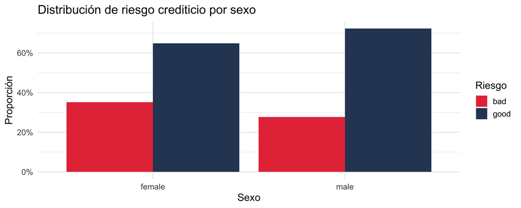

```r
R> # Distribución de Risk por Sex
R> german |>
+   count(Sex, Risk) |>
+   group_by(Sex) |>
+   mutate(prop = n / sum(n)) |>
+   ggplot(aes(x = Sex, y = prop, fill = Risk)) +
+   geom_col(position = "dodge") +
+   scale_fill_manual(values = c("good" = "#2d4563", "bad" = "#e63946")) +
+   scale_y_continuous(labels = scales::percent) +
+   labs(title = "Distribución de riesgo crediticio por sexo",
+        y = "Proporción", x = "Sexo", fill = "Riesgo") +
+   theme_minimal(base_size = 14)
```

Las tasas base son similares entre grupos, lo que facilita la comparación de métricas

## Preparar los datos

```r
R> # Dividir en train/test (estratificado por el resultado)
R> set.seed(123)
R> split <- initial_split(german, prop = 0.7, strata = Risk)
R> train_data <- training(split)
R> test_data <- testing(split)
R>
R> cat("Entrenamiento:", nrow(train_data), "filas\n")
```

```
Entrenamiento: 699 filas
```

```r
R> cat("Test:", nrow(test_data), "filas\n")
```

```
Test: 301 filas
```

Usaremos el conjunto de test para evaluar equidad, ya que representa datos no vistos

## Entrenar una regresión logística

```r
R> # Resultado binario y datos sin Sex (el atributo protegido)
R> datos_modelo <- train_data |>
+   mutate(buen_pagador = ifelse(Risk == "good", 1, 0)) |>
+   select(-Risk, -Sex)
R>
R> # Regresión logística: el clasificador clásico del día 2
R> modelo <- glm(buen_pagador ~ ., data = datos_modelo, family = binomial)
R>
R> # Probabilidad de "good" en test y decisión a 0.5
R> pred_probs <- predict(modelo, test_data, type = "response")
R> pred_class <- ifelse(pred_probs > 0.5, "good", "bad")
R>
R> # Accuracy global
R> accuracy <- mean(pred_class == test_data$Risk)
R> cat("Accuracy global:", round(accuracy, 3), "\n")
```

```
Accuracy global: 0.691
```

El modelo no usa Sex como variable, pero ¿eso garantiza que sea justo? La sesión 5.2 sugiere que no: los proxies existen

## Crear el explicador DALEX

```r
R> # Crear explicador DALEX
R> explainer <- DALEX::explain(
+   model = modelo,
+   data = test_data |> select(-Risk, -Sex),
+   y = as.numeric(test_data$Risk == "good"),
+   label = "Regresión logística",
+   verbose = FALSE
+ )
```

Ver [Wiśniewski y Biecek (2022)](https://arxiv.org/abs/2104.00507) para más detalles sobre los métodos de clasificación de sesgos

Un explicador es un objeto que envuelve todo lo que fairmodels necesita para auditar:

- El modelo entrenado
- Los datos de test
- La variable objetivo (0/1)

Para un `glm`, DALEX ya sabe cómo pedir las predicciones: no hace falta una función a medida

Es el paso intermedio: modelo → explicador → auditoría

## La auditoría: fairness_check()

```r
R> # Crear objeto fairness con Sex como atributo protegido
R> fobject <- fairness_check(
+   explainer,
+   protected = test_data$Sex,
+   privileged = "male",  # grupo de referencia
+   cutoff = 0.5,         # umbral de decisión
+   verbose = TRUE
+ )
```

```
Creating fairness classification object
-> Privileged subgroup      : character ( Ok  )
-> Protected variable       : factor ( Ok  )
-> Cutoff values for explainers : 0.5 ( for all subgroups )
-> Fairness objects     : 0 objects
-> Checking explainers      : 1 in total (  compatible  )
-> Metric calculation       : 13/13 metrics calculated for all models
 Fairness object created succesfully
```

```r
R> # Ver resumen
R> print(fobject)
```

```
Fairness check for models: Regresión logística

Regresión logística passes 4/5 metrics
Total loss :  0.4831363
```

El grupo privilegiado es el de referencia. Las métricas comparan otros grupos con este

## Visualizar métricas de equidad

La zona verde es la regla del 80% de la sesión 5.2: un ratio entre 0,8 y 1,25 se considera aceptable. Fuera de ella hay disparidad

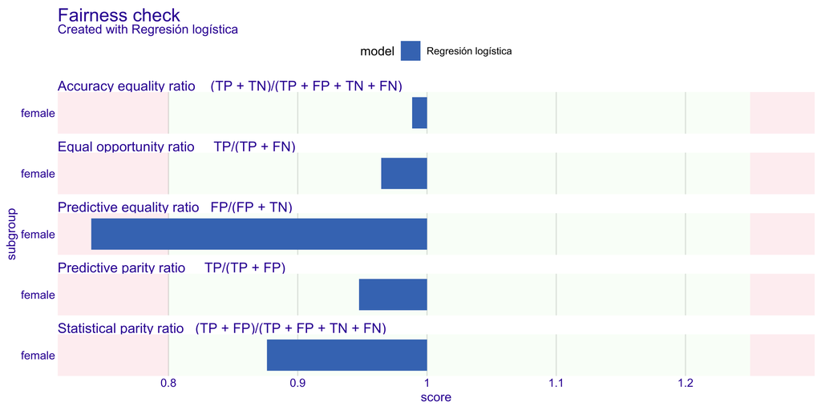

```r
R> plot(fobject)
```

## Interpretar las métricas

Cada fila de la salida (y cada barra del gráfico anterior) es un ratio entre grupos (mujeres ÷ hombres): 1,0 es igualdad perfecta y la zona verde (0,8 a 1,25) es la regla del 80%. El resultado “positivo” acá es recibir el crédito (que el modelo prediga `good`)

| Nombre en la salida | Fórmula | Qué pregunta, en crédito | En una frase |
| --- | --- | --- | --- |
| Accuracy equality (ACC) | (TP+TN)/total | ¿Acierta con la misma frecuencia en cada grupo? | Mismo nivel de aciertos |
| Equal opportunity (TPR) | TP/(TP+FN) | De quienes sí pagarían, ¿qué proporción recibe el crédito? | Igualdad de oportunidades |
| Predictive equality (FPR) | FP/(FP+TN) | De quienes no pagarían, ¿qué proporción se aprueba por error? | Mismo nivel de errores costosos |
| Predictive parity (PPV) | TP/(TP+FP) | De quienes el modelo aprueba, ¿qué proporción sí paga? | Calibración: “aprobado” significa lo mismo |
| Statistical parity (STP) | (TP+FP)/total | ¿Qué proporción de cada grupo recibe un “aprobado”? | Paridad demográfica |

La tabla de confusión, en crédito: TP aprobado y paga · FP aprobado y no paga · TN rechazado y no pagaría · FN rechazado pero sí pagaría

## Mitigación: umbrales diferenciados

Una estrategia de post-procesamiento (sesión 5.2): umbrales distintos por grupo para igualar un tipo de error

```r
R> # Un umbral por grupo: 0.5 para hombres, 0.4 para mujeres
R> umbral <- ifelse(test_data$Sex == "male", 0.5, 0.4)
R> mitigated_pred <- ifelse(pred_probs > umbral, "good", "bad")
R>
R> test_data |>
+   mutate(orig = pred_class, mitig = mitigated_pred) |>
+   group_by(Sex) |>
+   summarise(
+     fpr_orig = sum(orig == "good" & Risk == "bad") / sum(Risk == "bad"),
+     fpr_mitig = sum(mitig == "good" & Risk == "bad") / sum(Risk == "bad"),
+     acc_orig = mean(orig == Risk),
+     acc_mitig = mean(mitig == Risk),
+     .groups = "drop"
+   ) |>
+   mutate(across(where(is.numeric), ~round(., 3)))
```

```
# A tibble: 2 × 5
  Sex    fpr_orig fpr_mitig acc_orig acc_mitig
  <fct>     <dbl>     <dbl>    <dbl>     <dbl>
1 female    0.545     0.667    0.685     0.708
2 male      0.737     0.737    0.693     0.693
```

**Consideraciones**

- ¿Es justo usar umbrales diferentes por grupo? Algunos lo llaman discriminación inversa; otros, corrección de un sesgo sistémico
- La mitigación mueve el problema: mejora una métrica y empeora otra

La decisión de usar umbrales diferenciados es política, no técnica

Apéndice: explorar umbrales en detalle

# Discusión

## Actividad: recomendación al banco

**Escenario:**

Son consultores de un banco uruguayo que quiere implementar un modelo de scoring crediticio

El banco les pide una recomendación

**Preguntas para discutir (5 min):**

1. ¿Deberían usar umbrales diferenciados por sexo?
2. Si lo hacen, ¿es discriminación positiva o simplemente corrección de sesgo?
3. ¿Qué métrica de equidad priorizarían y por qué?
4. ¿Cómo comunicarían la decisión a los clientes?
5. ¿La ley uruguaya permite trato diferenciado por sexo en decisiones de crédito?

**Divídanse en grupos de 4**

# Ejercicios

## Ejercicio 1: mejorar el codebook

**Tarea (5 min):**

1. Copien `codebook_motivos` y agreguen a `instructions` reglas para los casos límite. Por ejemplo: si hay amenazas o temor a represalias, es `miedo` aunque también haya desconfianza
2. Re-codifiquen con `qlm_code()` y el modelo local
3. Vuelvan a correr `qlm_validate()` y comparen las métricas

**Pistas**

Solución

## Ejercicio 2: auditar con otra variable protegida

**Tarea:**

Repitan la auditoría de la Parte 2 usando edad como variable protegida.

1. Crear grupos de edad (jóvenes < 30, adultos 30-50, mayores > 50)
2. Crear un nuevo `fairness_check()` con esos grupos
3. Visualizar y identificar qué grupo es más perjudicado

**Código inicial:**

```r
R> test_data <- test_data |>
+   mutate(
+     Age_group = case_when(
+       Age < 30 ~ "joven",
+       Age < 50 ~ "adulto",
+       TRUE ~ "mayor"
+     )
+   )
R>
R> fobject_age <- fairness_check(
+   explainer,
+   protected = test_data$Age_group,
+   privileged = "adulto",
+   cutoff = 0.5,
+   verbose = FALSE
+ )
R>
R> plot(fobject_age)
```

**Preguntas a responder:**

1. ¿Qué grupo de edad tiene peor rendimiento?
2. ¿En qué métricas hay mayor disparidad?
3. ¿Tiene sentido que adultos sean el grupo privilegiado?
4. ¿Cómo se compara el sesgo por edad con el sesgo por sexo?

Trabajen individualmente o en parejas. Pueden consultar la documentación de fairmodels

Solución

## Resumen del laboratorio

**Parte 1: el modelo local**

- `chat_ollama()` y `model = "ollama/..."`: el flujo de los labs 7 y 8, sin que los datos salgan de la máquina
- El codebook con reglas de decisión es la herramienta para mejorar al codificador
- Validar contra gold standard sigue siendo obligatorio, local o nube

**Parte 2: la auditoría**

- Un modelo sin variables sensibles puede seguir siendo sesgado
- `fairness_check()` compara métricas entre grupos; la zona verde es la regla del 80%
- La mitigación implica trade-offs y las decisiones de equidad son políticas, no sólo técnicas

En la próxima sesión: mini-propuestas de investigación y cierre del curso

# Apéndice

## Solución Ejercicio 1

Un codebook con reglas de decisión para los casos límite:

```r
R> codebook_motivos_v2 <- qlm_codebook(
+   name = "motivos_no_denuncia_v2",
+   instructions = "Leé el fragmento de entrevista. La persona fue víctima de un delito
+   y no hizo la denuncia. Clasificá el MOTIVO PRINCIPAL en una de estas categorías:
+   - desconfianza: no cree que la policía o la justicia investiguen o resuelvan nada
+   - miedo: teme represalias del agresor o de su entorno
+   - costo: el trámite implica demasiado tiempo, viajes o burocracia
+   - poca_gravedad: considera que el hecho no fue suficientemente grave
+   - resolucion_propia: resolvió el problema por su cuenta o por otra vía
+   Reglas de decisión, en orden de prioridad:
+   1. Si menciona amenazas, represalias o temor por su seguridad o la de su familia,
+      es 'miedo', aunque también exprese desconfianza en la policía.
+   2. Si el problema ya se resolvió por otra vía (acuerdo, devolución, gestión propia),
+      es 'resolucion_propia', aunque el hecho fuera menor.
+   3. Si el obstáculo es el trámite (tiempo, distancia, burocracia, sistemas caídos),
+      es 'costo', aunque el monto perdido sea chico.
+   4. 'poca_gravedad' sólo cuando el argumento central es que el hecho no era serio.
+   Elegí UNA sola categoría.",
+   schema = type_object(
+     motivo = type_enum(
+       c("desconfianza", "miedo", "costo", "poca_gravedad", "resolucion_propia"),
+       "El motivo principal por el que no denunció"
+     ),
+     justificacion = type_string("Una oración que justifique la categoría elegida")
+   ),
+   role = "Sos un investigador experto en criminología y encuestas de victimización.",
+   levels = list(motivo = "nominal", justificacion = "nominal")
+ )
```

## Solución Ejercicio 1 (continuación)

```r
R> codificado_v2 <- qlm_code(
+   entrevistas$texto,
+   codebook_motivos_v2,
+   model = "ollama/granite4.1:3b",
+   max_active = 1,
+   params = params(temperature = 0),
+   name = "granite_local_v2"
+ )
R>
R> validacion_v2 <- qlm_validate(
+   codificado_v2,
+   gold = gold,
+   by = "motivo",
+   level = "nominal"
+ )
R>
R> as_tibble(validacion_v2) |> select(measure, value)
```

```
# A tibble: 5 × 2
  measure   value
  <chr>     <dbl>
1 accuracy      1
2 precision     1
3 recall        1
4 f1            1
5 kappa         1
```

- Comparen con la validación original. Con 16 textos, cada caso vale 6 puntos de accuracy, así que la mejora puede ser chica o nula en esta muestra. El efecto de las reglas se nota en corpus grandes y en la estabilidad entre corridas
- La lección metodológica: cuando el codificador falla, el primer sospechoso es el codebook, no el modelo

Volver al ejercicio

## Solución Ejercicio 2

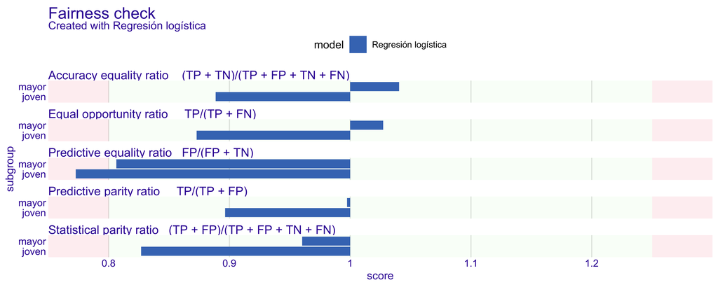

```r
R> # Crear grupos de edad
R> test_data <- test_data |>
+   mutate(
+     Age_group = case_when(
+       Age < 30 ~ "joven",
+       Age < 50 ~ "adulto",
+       TRUE ~ "mayor"
+     )
+   )
R>
R> # Crear objeto fairness por edad
R> fobject_age <- fairness_check(
+   explainer,
+   protected = test_data$Age_group,
+   privileged = "adulto",
+   cutoff = 0.5,
+   verbose = FALSE
+ )
R>
R> # Visualizar
R> plot(fobject_age)
```

Volver al ejercicio

## Apéndice: explorar umbrales en detalle

```r
R> # Función para calcular métricas con umbral personalizado
R> calc_metrics_threshold <- function(data, probs, threshold) {
+   pred <- ifelse(probs > threshold, "good", "bad")
+   data |>
+     mutate(pred = pred) |>
+     group_by(Sex) |>
+     summarise(
+       threshold = threshold,
+       accuracy = mean(pred == Risk),
+       tpr = sum(pred == "good" & Risk == "good") / sum(Risk == "good"),
+       fpr = sum(pred == "good" & Risk == "bad") / sum(Risk == "bad"),
+       .groups = "drop"
+     )
+ }
R>
R> # Probar varios umbrales
R> thresholds <- c(0.3, 0.4, 0.5, 0.6, 0.7)
R> results <- map_dfr(thresholds, ~calc_metrics_threshold(test_data, pred_probs, .x))
R>
R> results |>
+   arrange(Sex, threshold) |>
+   mutate(across(where(is.numeric), ~round(., 3)))
```

```
# A tibble: 10 × 5
   Sex    threshold accuracy   tpr   fpr
   <fct>      <dbl>    <dbl> <dbl> <dbl>
 1 female       0.3    0.674 0.982 0.848
 2 female       0.4    0.708 0.929 0.667
 3 female       0.5    0.685 0.821 0.545
 4 female       0.6    0.708 0.714 0.303
 5 female       0.7    0.663 0.607 0.242
 6 male         0.3    0.759 0.994 0.877
 7 male         0.4    0.731 0.935 0.825
 8 male         0.5    0.693 0.852 0.737
 9 male         0.6    0.679 0.748 0.509
10 male         0.7    0.651 0.671 0.404
```

Volver a mitigación

## Apéndice: visualizar el trade-off

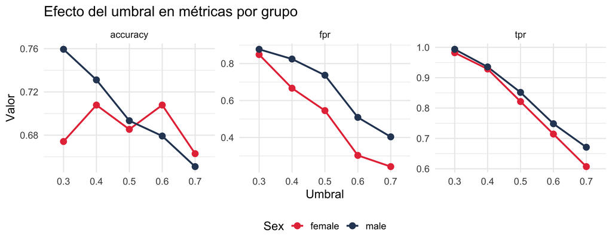

```r
R> results |>
+   pivot_longer(cols = c(accuracy, tpr, fpr), names_to = "metric", values_to = "value") |>
+   ggplot(aes(x = factor(threshold), y = value, color = Sex, group = Sex)) +
+   geom_line(linewidth = 1) +
+   geom_point(size = 3) +
+   facet_wrap(~metric, scales = "free_y") +
+   scale_color_manual(values = c("female" = "#e63946", "male" = "#2d4563")) +
+   labs(title = "Efecto del umbral en métricas por grupo",
+        x = "Umbral", y = "Valor") +
+   theme_minimal(base_size = 14) +
+   theme(legend.position = "bottom")
```

Diferentes umbrales afectan a los grupos de manera diferente. En crédito: un falso positivo es un préstamo que no se paga; un falso negativo, un buen cliente rechazado

Volver a mitigación

## Apéndice: ¿cuánta calidad cuesta la privacidad?

Si los datos no fueran sensibles, podríamos comparar el codificador local contra uno de la nube. `qlm_replicate()` acepta un modelo distinto:

```r
R> codificado_nube <- qlm_replicate(
+   codificado,
+   model = "openrouter/nvidia/nemotron-3-super-120b-a12b:free",
+   max_active = 3,
+   name = "nemotron_nube"
+ )
R>
R> qlm_compare(
+   codificado, codificado_nube,
+   by = "motivo", level = "nominal"
+ )
R>
R> qlm_validate(
+   codificado_nube,
+   gold = gold, by = "motivo", level = "nominal"
+ )
```

**Para qué sirve**

- `qlm_compare()` mide cuánto coinciden los dos codificadores
- Las dos validaciones contra el gold standard responden la pregunta de la sesión 5.1: ¿cuánta precisión cuesta correr local?

**Advertencia**

Requiere la API key de OpenRouter del lab 7, por eso no se ejecuta en estas diapositivas. Pruébenlo en casa con los datos simulados (nunca con datos sensibles reales)

# Nos vemos en la sesión 5.4 😊